# Coursera Project: Practical Machine Learning Modelling

Jayce Jocson

2023-08-03

# Executive Summary

The objective of this project is to develop a predictive model that can determine the manner in which participants performed an exercise based on the provided dataset. The dataset includes various variables that can be utilized for prediction. The data from accelerometers on the belt, forearm, arm, and dumbell of 6 participants to predict the manner in which they did the exercise. This report outlines the approach taken to build the model, the implementation of cross-validation, estimation of expected out-of-sample error, rationale for method choices, and the prediction results for 20 test cases.

The training and testing data for this project are available in the link below:

*Training Data:*

https://d396qusza40orc.cloudfront.net/predmachlearn/pml-training.csv

*Testing Data:*

https://d396qusza40orc.cloudfront.net/predmachlearn/pml-testing.csv

*Data of the source can be sourced in this web link:*

http://web.archive.org/web/20161224072740/http:/groupware.les.inf.puc-rio.br/har

## Methodology

### Load the data and libraries

```r
library(caret)
library(rpart)
library(rpart.plot)
library(corrplot)
library(lattice)
library(ggplot2)
set.seed(123)

traindata <- read.csv("pml-training.csv")
testdata <- read.csv("pml-testing.csv")

dim(traindata)
```

```
## [1] 19622   160
```

```r
dim(testdata)
```

```
## [1]  20 160
```

### Cleaning the training data

Removing the columns with missing values and irrelevant columns to the response.

```r
# Remove columns with more than 90% missing values
missing_threshold <- 0.9
columns_to_keep <- colMeans(is.na(traindata)) < missing_threshold
traindata <- traindata[, columns_to_keep]

# Remove irrelevant metadata columns (first 7 columns)
metadata_columns <- 1:7
traindata <- traindata[, -metadata_columns]

# Identify near-zero variance predictors in the traincsv dataset
nzv_columns <- nearZeroVar(traindata)
# Remove near-zero variance columns from the dataset
traindata <- traindata[, -nzv_columns]
dim(traindata)
```

```
## [1] 19622    53
```

### Create and Test Model

In this section we will create a model which is Random Forest and split the training data 70% for training set and the remaining 30% will be our testing. Let’s begin!

**Create the Random Forest Model**

```r
library(RWeka)
library(rJava)
set.seed(123)

#Spitting the Train Data for Training and Testing
train_ind = sample(1:nrow(traindata), size = floor(0.7*(nrow(traindata))))
datatrain = traindata[train_ind, ]
datatest = traindata[-train_ind, ]
features = 52
# Convert 'classe' to a nominal attribute
datatrain$classe <- as.factor(datatrain$classe)
datatest$classe <- as.factor(datatest$classe)
#Using Random Forest [Split Train Data]
RF = make_Weka_classifier("weka/classifiers/trees/RandomForest")
rfmodel = RF(classe ~ .,
             data = datatrain, control = Weka_control(K=floor(2*sqrt(features))))
datatest$predictions = predict(rfmodel, datatest)
```

**Create Predictions and Confusion Matrix**

```r
evaluate_Weka_classifier(rfmodel,newdata = datatest
                         ,numFolds = 5, class = TRUE, seed = 1)
```

```
## === 5 Fold Cross Validation ===
##
## === Summary ===
##
## Correctly Classified Instances        5855               99.4564 %
## Incorrectly Classified Instances        32                0.5436 %
## Kappa statistic                          0.9931
## Mean absolute error                      0.0065
## Root mean squared error                  0.0437
## Relative absolute error                  2.0691 %
## Root relative squared error             10.9905 %
## Total Number of Instances             5887
##
## === Detailed Accuracy By Class ===
##
##                  TP Rate  FP Rate  Precision  Recall   F-Measure  MCC      ROC Area  PRC Area  Class
##                  0.999    0.001    0.998      0.999    0.998      0.997    1.000     0.998     A
##                  0.995    0.001    0.995      0.995    0.995      0.993    0.999     0.997     B
##                  0.994    0.003    0.987      0.994    0.991      0.989    0.999     0.995     C
##                  0.986    0.001    0.994      0.986    0.990      0.988    0.998     0.995     D
##                  0.996    0.001    0.997      0.996    0.997      0.996    0.999     0.999     E
## Weighted Avg.    0.995    0.001    0.995      0.995    0.995      0.993    0.999     0.997
##
## === Confusion Matrix ===
##
##     a    b    c    d    e   <-- classified as
##  1662    2    0    0    0 |    a = A
##     4 1108    2    0    0 |    b = B
##     0    4 1020    2    0 |    c = C
##     0    0   11  961    3 |    d = D
##     0    0    0    4 1104 |    e = E
```

```r
prediction <- predict(rfmodel,datatest)
conf_mat <- confusionMatrix(prediction, factor(datatest$classe))
conf_mat
```

```
## Confusion Matrix and Statistics
##
##           Reference
## Prediction    A    B    C    D    E
##          A 1662    4    0    0    0
##          B    2 1108    4    0    0
##          C    0    2 1020   11    0
##          D    0    0    2  959    4
##          E    0    0    0    5 1104
##
## Overall Statistics
##
##                Accuracy : 0.9942
##                  95% CI : (0.9919, 0.996)
##     No Information Rate : 0.2827
##     P-Value [Acc > NIR] : < 2.2e-16
##
##                   Kappa : 0.9927
##
##  Mcnemar's Test P-Value : NA
##
## Statistics by Class:
##
##                      Class: A Class: B Class: C Class: D Class: E
## Sensitivity            0.9988   0.9946   0.9942   0.9836   0.9964
## Specificity            0.9991   0.9987   0.9973   0.9988   0.9990
## Pos Pred Value         0.9976   0.9946   0.9874   0.9938   0.9955
## Neg Pred Value         0.9995   0.9987   0.9988   0.9967   0.9992
## Prevalence             0.2827   0.1892   0.1743   0.1656   0.1882
## Detection Rate         0.2823   0.1882   0.1733   0.1629   0.1875
## Detection Prevalence   0.2830   0.1892   0.1755   0.1639   0.1884
## Balanced Accuracy      0.9989   0.9967   0.9957   0.9912   0.9977
```

*From our Random Forest, our model reach the metrics of* * Accuracy: **99.46%** * Out of Sample Error: 0.54%

## Create Prediction in PML Test Data

After creating the **RF model**, we will test it with the 20 rows to predict the classe response (A - E)

```r
testpredict <- predict(rfmodel, testdata)
testpredict
```

```
##  [1] B A B A A E D B A A B C B A E E A B B B
## Levels: A B C D E
```

## Conclusion

For a detailed analysis, code implementation, and visualization of results, please refer to the [GitHub repository](https://github.com/jayce0902/CP-Practical-Machine-Learning) containing the R markdown and compiled HTML file.

## Appendix: Figures

I. Correlation Matrix Visualization

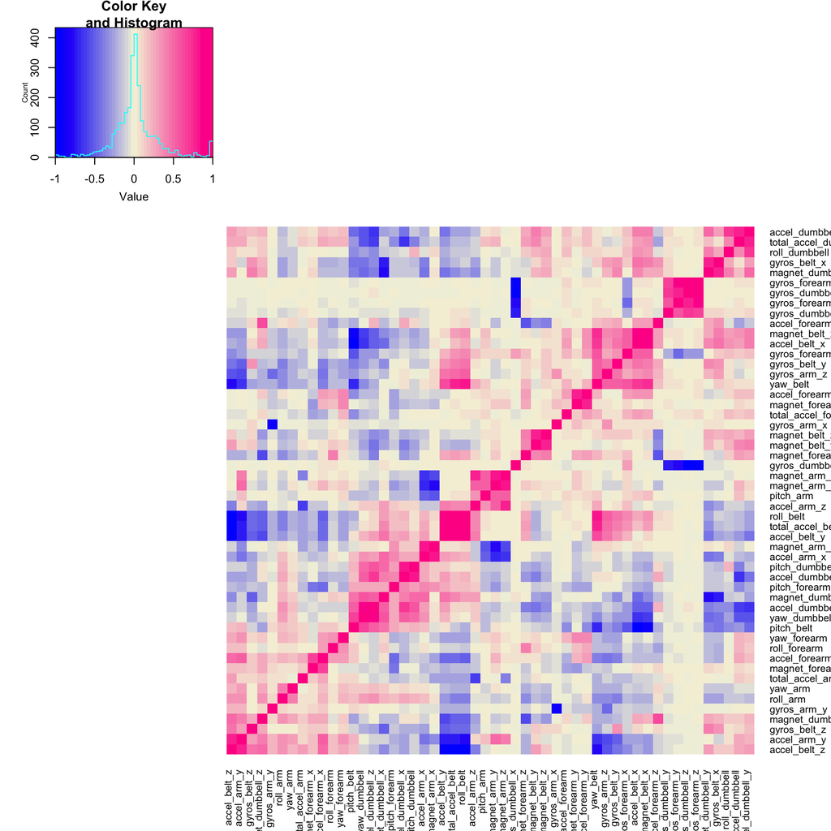